# Base R Basics

control flow, user-defined functions, & simulation

Presenter: Olivia Beck  
Content credit: Matthew Beckman

# Reminders

- Final Project Due Dates
  - June 21 @ 11:59pm: Initial EDA due
  - June 26 @ 11:59pm: Final Project Report + Checklist Due
- All late work due June 23 @ 11:59 pm.
- We will not be meeting over finals week

# Goals for today

1. in your adventures with R programming you’ll often encounter code written in base R, so we’ll meet some common syntax.
2. introduce loops as an intuitive approach to iterative tasks
3. meet the basic syntax to write your very own R functions
4. program a simulation study to better understand a counter-intuitive concept

e.g., Confidence interval statements:

> “We are 95% confident that the average amount of carbon stored in each square kilometer of tropical forest is between 9,600 and 13,600 tons”

> 95% CI: 11,600 ± 2⋅1000 = (9,600, 13,600)

What’s wrong with saying “there’s a 95% chance that the average amount of carbon stored in each square kilometer of tropical forest is between 9,600 and 13,600 tons” ??

# Some tools we’ll meet

- Facts & extensions from the reading
  - Create vectors using `c()`, `:`, `seq()`, `rep()`.
  - Subsetting
    - Subsetting with `[` (especially for vectors & data frames)
    - Subsetting with `$` (especially for data frames & lists)
    - Subsetting with `[[` (especially for lists)
  - Program using
    - `for` loop,
    - `while` loop,
    - `if` statements,
  - Write an original `function` (where have you done this before?)
- Nested loops (e.g., data frame indices)
- Extracting elements from arbitrary objects (e.g. a regression model object)
- Programming a simulation with & without loops
- [RStudio Cheat Sheet (on Canvas)](https://www.rstudio.com/wp-content/uploads/2016/05/base-r.pdf)

```r
rm(list = ls())

# no packages to load since we're talking about Base R!
```

# Creating vectors

#### `c( )` is most common by far

```r
grade <- c(2, 5, NA, 5)
grade
```

```
## [1]  2  5 NA  5
```

```r
mean(grade)
```

```
## [1] NA
```

```r
# we need argument `na.rm = TRUE
mean(grade, na.rm = TRUE)
```

```
## [1] 4
```

#### Shortcut using `:` for numbers in sequence

```r
2:6
```

```
## [1] 2 3 4 5 6
```

```r
twoThruSix <- 2:6
twoThruSix
```

```
## [1] 2 3 4 5 6
```

#### Sequences using `seq( )`

```r
seq(2, 5, by = 0.2)
```

```
##  [1] 2.0 2.2 2.4 2.6 2.8 3.0 3.2 3.4 3.6 3.8 4.0 4.2 4.4 4.6 4.8 5.0
```

```r
seq(2, 5, length.out = 15)
```

```
##  [1] 2.000000 2.214286 2.428571 2.642857 2.857143 3.071429 3.285714 3.500000
##  [9] 3.714286 3.928571 4.142857 4.357143 4.571429 4.785714 5.000000
```

#### Repeating a sequence using `rep( )`

```r
rep(c("A", "B", "C"), times = 3)
```

```
## [1] "A" "B" "C" "A" "B" "C" "A" "B" "C"
```

```r
rep(c("A", "B", "C"), each = 3)
```

```
## [1] "A" "A" "A" "B" "B" "B" "C" "C" "C"
```

# Selecting vector elements with square brackets

```r
# create a vector
x <- c("A", "B", "C", 1, 2, 3)
x
```

```
## [1] "A" "B" "C" "1" "2" "3"
```

#### Select only element 4

```r
x[4]
```

```
## [1] "1"
```

#### Select elements 2 thru 4

```r
x[2:4]
```

```
## [1] "B" "C" "1"
```

#### Select elements 1 and 5

```r
x[c(1, 5)]
```

```
## [1] "A" "2"
```

## Excluding Vector Elements with square brackets

```r
# create a vector
x <- c("A", "B", "C", 1, 2, 3)
x
```

```
## [1] "A" "B" "C" "1" "2" "3"
```

#### Select all elements except element 4

```r
x[-4]
```

```
## [1] "A" "B" "C" "2" "3"
```

#### Select all elements except elements 1, 4, and 6

```r
x[-c(1, 4, 6)]
```

```
## [1] "B" "C" "2"
```

## Square Brackets and Data Frames

We discussed using `[[ ]]` for lists in Week 10.

#### A special case of a list where all elements are the same length.

```r
lets <- c("A", "B", "C", "D", "E", "F")    # create a vector
numbers <- 1:6                                # create another vector

df <- data.frame(numbers, lets)            # combine them as a data frame
df
```

```
##   numbers lets
## 1       1    A
## 2       2    B
## 3       3    C
## 4       4    D
## 5       5    E
## 6       6    F
```

You can use square brackets to select specific elements based on [row, column].

#### Select element in row 3 and column 2

```r
df[3, 2]
```

```
## [1] "C"
```

#### Select all elements in row 4 (note comma placement)

```r
df[4, ]
```

```
##   numbers lets
## 4       4    D
```

#### Select all elements in column 2 (again, note comma placement)

```r
df[ , 2]
```

```
## [1] "A" "B" "C" "D" "E" "F"
```

# Selecting Vector Elements that match a Condition

```r
# create a vector of numbers
set.seed(184)
y <- sample(letters, 10, replace = TRUE)
y
```

```
##  [1] "s" "h" "f" "n" "g" "f" "n" "i" "f" "u"
```

#### Select elements equal to “g”

```r
y == "g"
```

```
##  [1] FALSE FALSE FALSE FALSE  TRUE FALSE FALSE FALSE FALSE FALSE
```

```r
y[y == "g"]
```

```
## [1] "g"
```

#### Select elements in the set {e, f, g}

```r
y[y %in% c("e", "f", "g")]
```

```
## [1] "f" "g" "f" "f"
```

#### What if instead we wanted the index of the values that match our condition?

```r
which(y %in% c("e", "f", "g"))
```

```
## [1] 3 5 6 9
```

We can get the same answer two differnt ways

```r
y[y %in% c("e", "f", "g")]
```

```
## [1] "f" "g" "f" "f"
```

```r
y[which(y %in% c("e", "f", "g"))]
```

```
## [1] "f" "g" "f" "f"
```

# The dollar sign `$` operator for data frames

```r
numbers = 1:26
letters = base::letters

df <- data.frame(numbers, letters)    # same data frame used before
df
```

```
##    numbers letters
## 1        1       a
## 2        2       b
## 3        3       c
## 4        4       d
## 5        5       e
## 6        6       f
## 7        7       g
## 8        8       h
## 9        9       i
## 10      10       j
## 11      11       k
## 12      12       l
## 13      13       m
## 14      14       n
## 15      15       o
## 16      16       p
## 17      17       q
## 18      18       r
## 19      19       s
## 20      20       t
## 21      21       u
## 22      22       v
## 23      23       w
## 24      24       x
## 25      25       y
## 26      26       z
```

#### Dollar sign `$` used to select a variable in a data frame by name (and simplify class)

```r
df$numbers
```

```
##  [1]  1  2  3  4  5  6  7  8  9 10 11 12 13 14 15 16 17 18 19 20 21 22 23 24 25
## [26] 26
```

#### Adding variables to data frames

```r
df$combo <- paste(letters, "-", numbers, "combo")   # paste is a handy function too

df$uppercase <- base::LETTERS

df$states <- NA #initialize
for(i in 1:nrow(df)){
  df$states[i] <- datasets::state.abb[i]
}

df
```

```
##    numbers letters        combo uppercase states
## 1        1       a  a - 1 combo         A     AL
## 2        2       b  b - 2 combo         B     AK
## 3        3       c  c - 3 combo         C     AZ
## 4        4       d  d - 4 combo         D     AR
## 5        5       e  e - 5 combo         E     CA
## 6        6       f  f - 6 combo         F     CO
## 7        7       g  g - 7 combo         G     CT
## 8        8       h  h - 8 combo         H     DE
## 9        9       i  i - 9 combo         I     FL
## 10      10       j j - 10 combo         J     GA
## 11      11       k k - 11 combo         K     HI
## 12      12       l l - 12 combo         L     ID
## 13      13       m m - 13 combo         M     IL
## 14      14       n n - 14 combo         N     IN
## 15      15       o o - 15 combo         O     IA
## 16      16       p p - 16 combo         P     KS
## 17      17       q q - 17 combo         Q     KY
## 18      18       r r - 18 combo         R     LA
## 19      19       s s - 19 combo         S     ME
## 20      20       t t - 20 combo         T     MD
## 21      21       u u - 21 combo         U     MA
## 22      22       v v - 22 combo         V     MI
## 23      23       w w - 23 combo         W     MN
## 24      24       x x - 24 combo         X     MS
## 25      25       y y - 25 combo         Y     MO
## 26      26       z z - 26 combo         Z     MT
```

# Programming with `for` Loops

#### Basic `for` Loop Syntax:

```
for (index in sequence) {
  do something
}
```

#### Here’s a `for` loop that will “do something” for each number from 1 to 4

```r
for (i in 1:4) {
  j <- i + 10     # add 10 to the "current" value of `i` in each step of the loop
  print(j)        # print the result of `j` for each step of the loop
}
```

```
## [1] 11
## [1] 12
## [1] 13
## [1] 14
```

#### This is often used to iterate over each value in a vector where x[i] refers to element `i` of the vector `x`

Goal: Divide each number in the `byFives` vector by 3.

```r
byFives <- seq(0, 100, by = 5)   # vector counts by 5
byFives
```

```
##  [1]   0   5  10  15  20  25  30  35  40  45  50  55  60  65  70  75  80  85  90
## [20]  95 100
```

```r
for (i in 1:length(byFives)) {  # `length(byFives)` is the number of elements in the `byFives` vector
  j <- byFives[i] / 3           # divide element `i` of the `fives` vector by 3 in each step of the loop
  print(j)                      # print the result of `j` for each step of the loop
}
```

```
## [1] 0
## [1] 1.666667
## [1] 3.333333
## [1] 5
## [1] 6.666667
## [1] 8.333333
## [1] 10
## [1] 11.66667
## [1] 13.33333
## [1] 15
## [1] 16.66667
## [1] 18.33333
## [1] 20
## [1] 21.66667
## [1] 23.33333
## [1] 25
## [1] 26.66667
## [1] 28.33333
## [1] 30
## [1] 31.66667
## [1] 33.33333
```

#### Another For loop

Usually you do a for loops because you want a repeated calculation

Goal : for all numbers between 10 and 37, tell me if each number is divisible by 5.

Method 1: Use for loops

```r
numbers <- seq(10, 37, by = 1)   # vector counts by1
numbers
```

```
##  [1] 10 11 12 13 14 15 16 17 18 19 20 21 22 23 24 25 26 27 28 29 30 31 32 33 34
## [26] 35 36 37
```

```r
DivisableBy5 <- rep(NA, length(numbers)) #initialize storage

## Do it in a for loop
for (i in 1:length(numbers)) {
  remainder <-  numbers[i] %% 5
  if(remainder == 0){
    DivisableBy5[i] <- TRUE
  }else(
    DivisableBy5[i] <- FALSE
  )
}

DivisableBy5
```

```
##  [1]  TRUE FALSE FALSE FALSE FALSE  TRUE FALSE FALSE FALSE FALSE  TRUE FALSE
## [13] FALSE FALSE FALSE  TRUE FALSE FALSE FALSE FALSE  TRUE FALSE FALSE FALSE
## [25] FALSE  TRUE FALSE FALSE
```

```r
#display the numbers that are divisable by 5
numbers[DivisableBy5]
```

```
## [1] 10 15 20 25 30 35
```

Method 2: Use vectorization

```r
numbers %% 5 == 0
```

```
##  [1]  TRUE FALSE FALSE FALSE FALSE  TRUE FALSE FALSE FALSE FALSE  TRUE FALSE
## [13] FALSE FALSE FALSE  TRUE FALSE FALSE FALSE FALSE  TRUE FALSE FALSE FALSE
## [25] FALSE  TRUE FALSE FALSE
```

```r
numbers[ numbers %% 5 == 0 ]
```

```
## [1] 10 15 20 25 30 35
```

Verify our two answers match - sum all answers that don’t match. If our two answers match, this will be 0.

```r
for.loop <- DivisableBy5
vectorization <- numbers %% 5 == 0

sum(for.loop != vectorization) # =0, we are good!
```

```
## [1] 0
```

## This is a different way of doing a for loop that achieves the same goal

note the subtle differences in the `for` statement.

```r
numbers <- seq(10, 37, by = 1)   # vector counts by1
DivisableBy5 <- rep(NA, length(numbers))

index5 = 1

for (i in numbers) {
  remainder <-  i %% 5
  if(remainder == 0){
    DivisableBy5[index5] <- TRUE
  }else(
    DivisableBy5[index5] <- FALSE
  )
  index5 <- index5 + 1
}

DivisableBy5
```

```
##  [1]  TRUE FALSE FALSE FALSE FALSE  TRUE FALSE FALSE FALSE FALSE  TRUE FALSE
## [13] FALSE FALSE FALSE  TRUE FALSE FALSE FALSE FALSE  TRUE FALSE FALSE FALSE
## [25] FALSE  TRUE FALSE FALSE
```

```r
numbers[DivisableBy5]
```

```
## [1] 10 15 20 25 30 35
```

# Programming with `while` Loops

#### Basic `while` Loop Syntax:

```
while (true condition){
  do something
}
```

**CAUTION: don’t get stuck in an endless loop!**

Example of a `while` loop that will never end because the “true condition” is always true:

```
a <- 0
while(1<2){
  a <- a +1
}
```

- if you do get stuck, put your cursor in your Console and press ESC or click the “Stop Sign” at the top right corner or the Console.

#### Here’s a `while` loop that prints the index `i` while it is less than 5:

```r
i <- 1            # initialize our index variable

while (i < 5) {   # set the condition of the `while` loop
  print(i)        # print the value of `i` in each step of the loop
  i <- i + 1      # increment `i` for the next trip through the loop
}
```

```
## [1] 1
## [1] 2
## [1] 3
## [1] 4
```

# Building loops

### `for` versus `while`

- Do you know how many times you need to repeat?
  - yes: `for`
  - no: `while`

### Initalizing Memory

- Do you know the dimensions of the object you want to store?
  - yes: initialize the exact size. e.g. `a <- rep(0, 10)`
  - no: initialize an empty object and expand it as needed. e.g. `a <- c()`.

#### Advanced Side Note:

- When we initialize the exact size of an object, this is called static memory.
  - Inefficient in memory storage
  - Efficient for computation time on large objects
- When we initialize an empty object and expand it as needed, this is called dynamic memory.
  - Efficient in memory storage
  - Inefficient for computation time on large objects

Here are some resources about memory usage in R: - http://adv-r.had.co.nz/memory.html

# Programming with functions (that you build yourself!)

#### Basic `function` Syntax:

```
function_name <- function(arg1) {
  do something
  return(new_object)
}
```

#### Here’s a function that takes one number as an argument and squares it:

```r
squared <- function(x) {       # the function will be called "squared" and takes one argument
  calculation <- x * x         # this shows what the function will do with the `x` argument
  return(calculation)          # this tells the function to display the result of `calculation`
}

#note that `calculation` only "lives" inside of `squared`.
#It is NOT in your global environment when you run the `squared` function.


# Nothing happens until you call the new `squared( )` function that you've created:
squared(3)
```

```
## [1] 9
```

# Programming with conditional flow (if-else)

#### Basic `if` Statement Syntax:

```
if (condition) {
  do something
} else {
  do something different
}
```

```r
var <- 5           # some variable set to 5

if (var > 3) {     # if condition
  print('Yes')     # do this if condition is satisfied
} else {
  print('No')      # do this if condition is NOT satisfied
}
```

```
## [1] "Yes"
```

#### Let’s re-write our `squared` function with a fail-safe

```r
squared_better <- function(x) {       # the function will be called "squared" and takes one argument
  if (!is.numeric(x)) {
    print("Error: This function requires a numeric argument!")
  } else {
  calculation <- x * x         # this shows what the function will do with the `x` argument
  return(calculation)          # this tells the function to display the result of `calculation`
  }
}

#squared("1")
squared_better("1")
```

```
## [1] "Error: This function requires a numeric argument!"
```

These `if` statements work well with other programming tools:

- Inside a loop you might test a condition with each iteration through the loop and provide alternate instructions depending on the outcome.
- As part of a `function` you might provide different instructions depending on the argument supplied.

#### Fine to link as many conditions as needed:

```
if (condition){
  do something
} else if (another condition) {
  do something else
} else {
  do something different
}
```

# Nested looping (e.g., over rows and columns)

```r
df2 <- data.frame(NULL)  # we need a placeholder, and it should be a data.frame
Rows <- c(1:6)
Cols <- c(1:5)


for (j in 1:length(Cols)) {           # outer loop processed after each complete cycle of inner loop
  for (i in 1:length(Rows)) {         # inner loop processed most frequently
    df2[i, j] <- paste("Row", i, ", Col", j)
  }
}

df2
```

```
##              V1            V2            V3            V4            V5
## 1 Row 1 , Col 1 Row 1 , Col 2 Row 1 , Col 3 Row 1 , Col 4 Row 1 , Col 5
## 2 Row 2 , Col 1 Row 2 , Col 2 Row 2 , Col 3 Row 2 , Col 4 Row 2 , Col 5
## 3 Row 3 , Col 1 Row 3 , Col 2 Row 3 , Col 3 Row 3 , Col 4 Row 3 , Col 5
## 4 Row 4 , Col 1 Row 4 , Col 2 Row 4 , Col 3 Row 4 , Col 4 Row 4 , Col 5
## 5 Row 5 , Col 1 Row 5 , Col 2 Row 5 , Col 3 Row 5 , Col 4 Row 5 , Col 5
## 6 Row 6 , Col 1 Row 6 , Col 2 Row 6 , Col 3 Row 6 , Col 4 Row 6 , Col 5
```

## Dollar sign `$` operator for other objects

#### Consider a simple linear regression model (`mtcars` data set):

```r
# this is a model predicting miles per gallon from weight of the car
CarModel <- lm(mpg ~ wt, data = mtcars)

# same model, different syntax--harder to read, but $ helps auto-fill variable names
CarModel2 <- lm(mtcars$mpg ~ mtcars$wt)
```

#### The `summary( )` command will provide a useful summary of the model information

```r
summary(CarModel)
```

```
##
## Call:
## lm(formula = mpg ~ wt, data = mtcars)
##
## Residuals:
##     Min      1Q  Median      3Q     Max
## -4.5432 -2.3647 -0.1252  1.4096  6.8727
##
## Coefficients:
##             Estimate Std. Error t value Pr(>|t|)
## (Intercept)  37.2851     1.8776  19.858  < 2e-16 ***
## wt           -5.3445     0.5591  -9.559 1.29e-10 ***
## ---
## Signif. codes:  0 '***' 0.001 '**' 0.01 '*' 0.05 '.' 0.1 ' ' 1
##
## Residual standard error: 3.046 on 30 degrees of freedom
## Multiple R-squared:  0.7528, Adjusted R-squared:  0.7446
## F-statistic: 91.38 on 1 and 30 DF,  p-value: 1.294e-10
```

#### The `CarModel` object includes lots more though, as we can see through an `str()` command

```r
library(tidyverse)
glimpse(CarModel)
```

```
## List of 12
##  $ coefficients : Named num [1:2] 37.29 -5.34
##   ..- attr(*, "names")= chr [1:2] "(Intercept)" "wt"
##  $ residuals    : Named num [1:32] -2.28 -0.92 -2.09 1.3 -0.2 ...
##   ..- attr(*, "names")= chr [1:32] "Mazda RX4" "Mazda RX4 Wag" "Datsun 710" "Hornet 4 Drive" ...
##  $ effects      : Named num [1:32] -113.65 -29.116 -1.661 1.631 0.111 ...
##   ..- attr(*, "names")= chr [1:32] "(Intercept)" "wt" "" "" ...
##  $ rank         : int 2
##  $ fitted.values: Named num [1:32] 23.3 21.9 24.9 20.1 18.9 ...
##   ..- attr(*, "names")= chr [1:32] "Mazda RX4" "Mazda RX4 Wag" "Datsun 710" "Hornet 4 Drive" ...
##  $ assign       : int [1:2] 0 1
##  $ qr           :List of 5
##   ..$ qr   : num [1:32, 1:2] -5.657 0.177 0.177 0.177 0.177 ...
##   .. ..- attr(*, "dimnames")=List of 2
##   .. ..- attr(*, "assign")= int [1:2] 0 1
##   ..$ qraux: num [1:2] 1.18 1.05
##   ..$ pivot: int [1:2] 1 2
##   ..$ tol  : num 1e-07
##   ..$ rank : int 2
##   ..- attr(*, "class")= chr "qr"
##  $ df.residual  : int 30
##  $ xlevels      : Named list()
##  $ call         : language lm(formula = mpg ~ wt, data = mtcars)
##  $ terms        :Classes 'terms', 'formula'  language mpg ~ wt
##   .. ..- attr(*, "variables")= language list(mpg, wt)
##   .. ..- attr(*, "factors")= int [1:2, 1] 0 1
##   .. .. ..- attr(*, "dimnames")=List of 2
##   .. ..- attr(*, "term.labels")= chr "wt"
##   .. ..- attr(*, "order")= int 1
##   .. ..- attr(*, "intercept")= int 1
##   .. ..- attr(*, "response")= int 1
##   .. ..- attr(*, ".Environment")=<environment: R_GlobalEnv>
##   .. ..- attr(*, "predvars")= language list(mpg, wt)
##   .. ..- attr(*, "dataClasses")= Named chr [1:2] "numeric" "numeric"
##   .. .. ..- attr(*, "names")= chr [1:2] "mpg" "wt"
##  $ model        :'data.frame':   32 obs. of  2 variables:
##   ..$ mpg: num [1:32] 21 21 22.8 21.4 18.7 18.1 14.3 24.4 22.8 19.2 ...
##   ..$ wt : num [1:32] 2.62 2.88 2.32 3.21 3.44 ...
##   ..- attr(*, "terms")=Classes 'terms', 'formula'  language mpg ~ wt
##   .. .. ..- attr(*, "variables")= language list(mpg, wt)
##   .. .. ..- attr(*, "factors")= int [1:2, 1] 0 1
##   .. .. .. ..- attr(*, "dimnames")=List of 2
##   .. .. ..- attr(*, "term.labels")= chr "wt"
##   .. .. ..- attr(*, "order")= int 1
##   .. .. ..- attr(*, "intercept")= int 1
##   .. .. ..- attr(*, "response")= int 1
##   .. .. ..- attr(*, ".Environment")=<environment: R_GlobalEnv>
##   .. .. ..- attr(*, "predvars")= language list(mpg, wt)
##   .. .. ..- attr(*, "dataClasses")= Named chr [1:2] "numeric" "numeric"
##   .. .. .. ..- attr(*, "names")= chr [1:2] "mpg" "wt"
##  - attr(*, "class")= chr "lm"
```

We can extract that information from `CarModel` using the dollar sign `$` operator.

How about coefficient estimates:

```r
CarModel$coefficients
```

```
## (Intercept)          wt
##   37.285126   -5.344472
```

```r
# compare methods to select various elements...

# double square brackets
CarModel[["model"]]
```

```
##                      mpg    wt
## Mazda RX4           21.0 2.620
## Mazda RX4 Wag       21.0 2.875
## Datsun 710          22.8 2.320
## Hornet 4 Drive      21.4 3.215
## Hornet Sportabout   18.7 3.440
## Valiant             18.1 3.460
## Duster 360          14.3 3.570
## Merc 240D           24.4 3.190
## Merc 230            22.8 3.150
## Merc 280            19.2 3.440
## Merc 280C           17.8 3.440
## Merc 450SE          16.4 4.070
## Merc 450SL          17.3 3.730
## Merc 450SLC         15.2 3.780
## Cadillac Fleetwood  10.4 5.250
## Lincoln Continental 10.4 5.424
## Chrysler Imperial   14.7 5.345
## Fiat 128            32.4 2.200
## Honda Civic         30.4 1.615
## Toyota Corolla      33.9 1.835
## Toyota Corona       21.5 2.465
## Dodge Challenger    15.5 3.520
## AMC Javelin         15.2 3.435
## Camaro Z28          13.3 3.840
## Pontiac Firebird    19.2 3.845
## Fiat X1-9           27.3 1.935
## Porsche 914-2       26.0 2.140
## Lotus Europa        30.4 1.513
## Ford Pantera L      15.8 3.170
## Ferrari Dino        19.7 2.770
## Maserati Bora       15.0 3.570
## Volvo 142E          21.4 2.780
```

```r
CarModel[["coefficients"]]
```

```
## (Intercept)          wt
##   37.285126   -5.344472
```

```r
# dollar sign
CarModel$model
```

```
##                      mpg    wt
## Mazda RX4           21.0 2.620
## Mazda RX4 Wag       21.0 2.875
## Datsun 710          22.8 2.320
## Hornet 4 Drive      21.4 3.215
## Hornet Sportabout   18.7 3.440
## Valiant             18.1 3.460
## Duster 360          14.3 3.570
## Merc 240D           24.4 3.190
## Merc 230            22.8 3.150
## Merc 280            19.2 3.440
## Merc 280C           17.8 3.440
## Merc 450SE          16.4 4.070
## Merc 450SL          17.3 3.730
## Merc 450SLC         15.2 3.780
## Cadillac Fleetwood  10.4 5.250
## Lincoln Continental 10.4 5.424
## Chrysler Imperial   14.7 5.345
## Fiat 128            32.4 2.200
## Honda Civic         30.4 1.615
## Toyota Corolla      33.9 1.835
## Toyota Corona       21.5 2.465
## Dodge Challenger    15.5 3.520
## AMC Javelin         15.2 3.435
## Camaro Z28          13.3 3.840
## Pontiac Firebird    19.2 3.845
## Fiat X1-9           27.3 1.935
## Porsche 914-2       26.0 2.140
## Lotus Europa        30.4 1.513
## Ford Pantera L      15.8 3.170
## Ferrari Dino        19.7 2.770
## Maserati Bora       15.0 3.570
## Volvo 142E          21.4 2.780
```

```r
CarModel$coefficients
```

```
## (Intercept)          wt
##   37.285126   -5.344472
```

```r
# single square brackets... what do you expect from [ ...] ?  Would that make sense here?
CarModel["model"]
```

```
## $model
##                      mpg    wt
## Mazda RX4           21.0 2.620
## Mazda RX4 Wag       21.0 2.875
## Datsun 710          22.8 2.320
## Hornet 4 Drive      21.4 3.215
## Hornet Sportabout   18.7 3.440
## Valiant             18.1 3.460
## Duster 360          14.3 3.570
## Merc 240D           24.4 3.190
## Merc 230            22.8 3.150
## Merc 280            19.2 3.440
## Merc 280C           17.8 3.440
## Merc 450SE          16.4 4.070
## Merc 450SL          17.3 3.730
## Merc 450SLC         15.2 3.780
## Cadillac Fleetwood  10.4 5.250
## Lincoln Continental 10.4 5.424
## Chrysler Imperial   14.7 5.345
## Fiat 128            32.4 2.200
## Honda Civic         30.4 1.615
## Toyota Corolla      33.9 1.835
## Toyota Corona       21.5 2.465
## Dodge Challenger    15.5 3.520
## AMC Javelin         15.2 3.435
## Camaro Z28          13.3 3.840
## Pontiac Firebird    19.2 3.845
## Fiat X1-9           27.3 1.935
## Porsche 914-2       26.0 2.140
## Lotus Europa        30.4 1.513
## Ford Pantera L      15.8 3.170
## Ferrari Dino        19.7 2.770
## Maserati Bora       15.0 3.570
## Volvo 142E          21.4 2.780
```

```r
CarModel["coefficients"]
```

```
## $coefficients
## (Intercept)          wt
##   37.285126   -5.344472
```

We often show residuals vs fitted values to evaluate a `CarModel` fit. The `CarModel` object stores that information for your use, so you can extract it with the `$` operator to easily retrieve it:

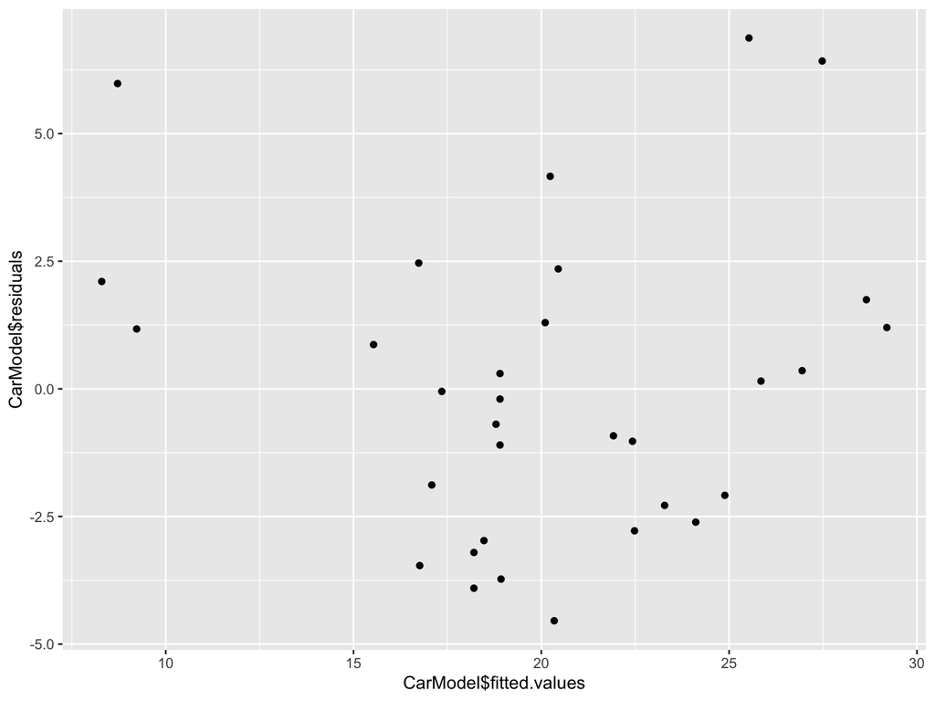

```r
library(tidyverse)

require(ggplot2)    # note--base r does plots too, but `ggplot2` gives you much more control

ggplot() +
  geom_point(aes(x = CarModel$fitted.values, y = CarModel$residuals))
```

For the sake of illustration, suppose you want to color the residuals by the number of cylinders as a proxy for engine size. (note it would usually make more sense to include cylinder as a variable in the model, but we’re just showing a way that you can pull information from compatible data sets together on a plot)

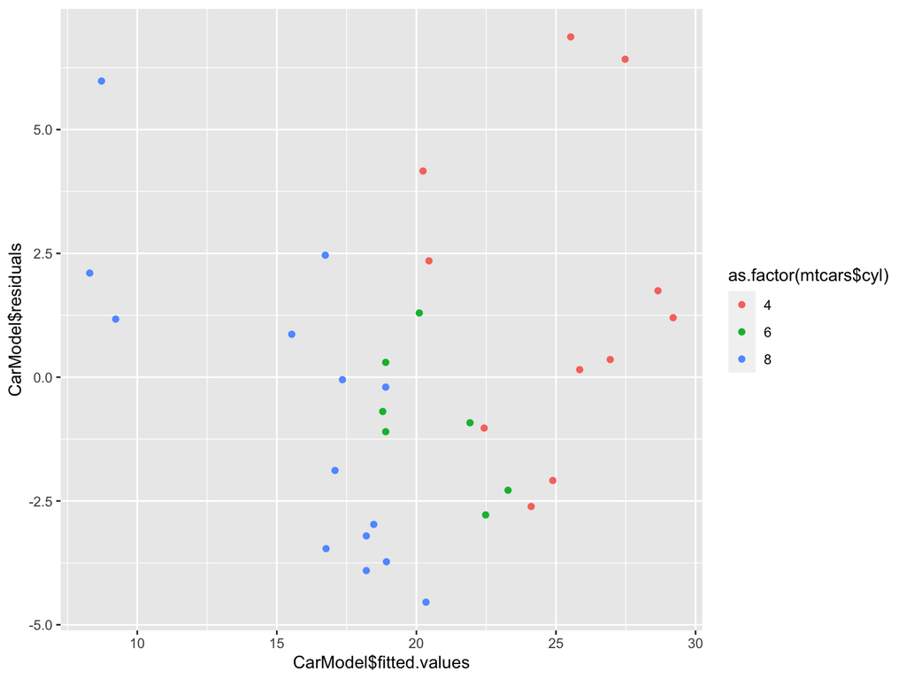

```r
require(ggplot2)

ggplot() +
  geom_point(aes(x = CarModel$fitted.values, y = CarModel$residuals, color = as.factor(mtcars$cyl)))
```

# Simulation

#### Result from a real study about carbon capture in tropical forests:

> 95% CI: 11,600 ± 2⋅1000 = (9,600, 13,600)

> “We are 95% confident that the average amount of carbon stored in each square kilometer of tropical forest is between 9,600 and 13,600 tons”

What’s wrong with saying “there’s a 95% chance that the average amount of carbon stored in each square kilometer of tropical forest is between 9,600 and 13,600 tons” ??

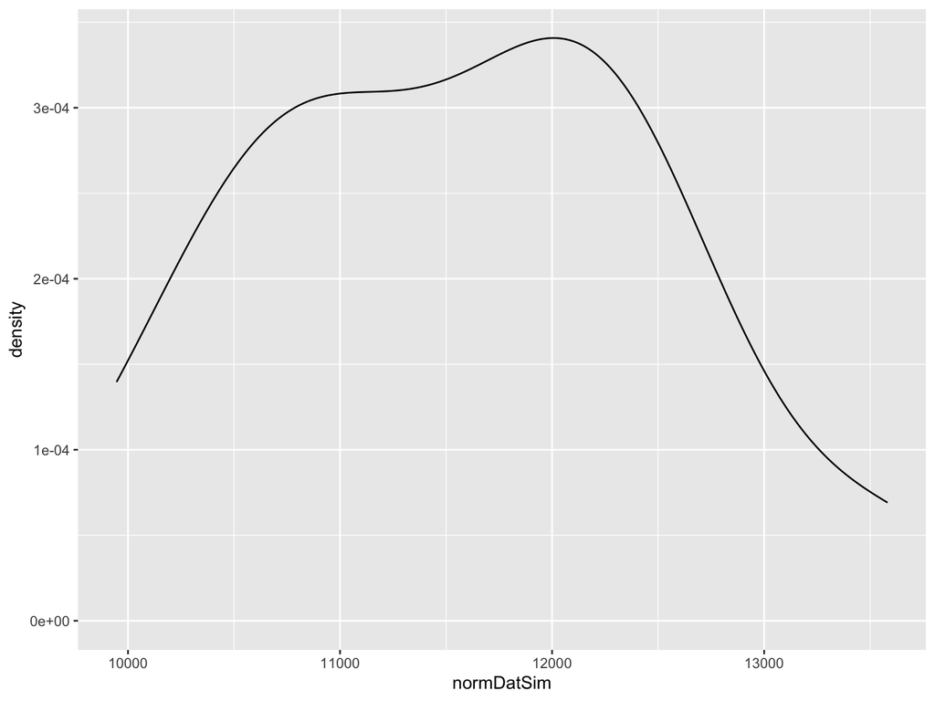

```r
normDatSim <- rnorm(n = 15, mean = 11600, sd = 1000)
# normDatSim <- rexp(n = 15, rate = 1/11600)  # a non-normal distribution for comparison

ggplot() +
  geom_density(aes(normDatSim))
```

```r
t.test(normDatSim)
```

```
##
##  One Sample t-test
##
## data:  normDatSim
## t = 45.789, df = 14, p-value < 2.2e-16
## alternative hypothesis: true mean is not equal to 0
## 95 percent confidence interval:
##  11040.31 12125.40
## sample estimates:
## mean of x
##  11582.86
```

# Simulation with Loops

```r
# simulation settings
nsimulations <- 100
mu <- 11600
sigma <- 1000
sampleSize <- 15

# initialize a data frame where we can store various results at each step in our simulation
ConfIntDat <- data.frame(simulationID = rep(NA, nsimulations),
                         lower = rep(NA, nsimulations),
                         upper = rep(NA, nsimulations),
                         captureMu = rep(NA, nsimulations))

# use a loop to simulate many results and store them at each step
for (i in 1:nsimulations) {                                   # increment 'i' from 1 to 'nsimulations'
  normDatSim <- rnorm(n = sampleSize, mean = mu, sd = sigma)  # simulate a new random sample
  ConfIntDat$simulationID[i] <- i                             # store an ID for each sample
  ConfIntDat$lower[i] <- t.test(normDatSim)$conf.int[1]       # store the lower bound of our CI
  ConfIntDat$upper[i] <- t.test(normDatSim)$conf.int[2]       # store upper bound of our CI
  ConfIntDat$captureMu[i] <- (mu > ConfIntDat$lower[i] & mu < ConfIntDat$upper[i])

}

ConfIntDat
```

```
##     simulationID    lower    upper captureMu
## 1              1 10701.59 11987.69      TRUE
## 2              2 11438.79 12444.62      TRUE
## 3              3 10492.32 11632.62      TRUE
## 4              4 11237.70 12322.92      TRUE
## 5              5 10803.74 12055.37      TRUE
## 6              6 10885.15 11899.97      TRUE
## 7              7 10814.52 12042.70      TRUE
## 8              8 10829.82 12176.37      TRUE
## 9              9 11039.27 12313.03      TRUE
## 10            10 10858.26 12144.78      TRUE
## 11            11 11468.03 12545.03      TRUE
## 12            12 11274.46 12161.99      TRUE
## 13            13 10621.99 11821.16      TRUE
## 14            14 11030.38 12277.46      TRUE
```

[output cut: 86 more lines]

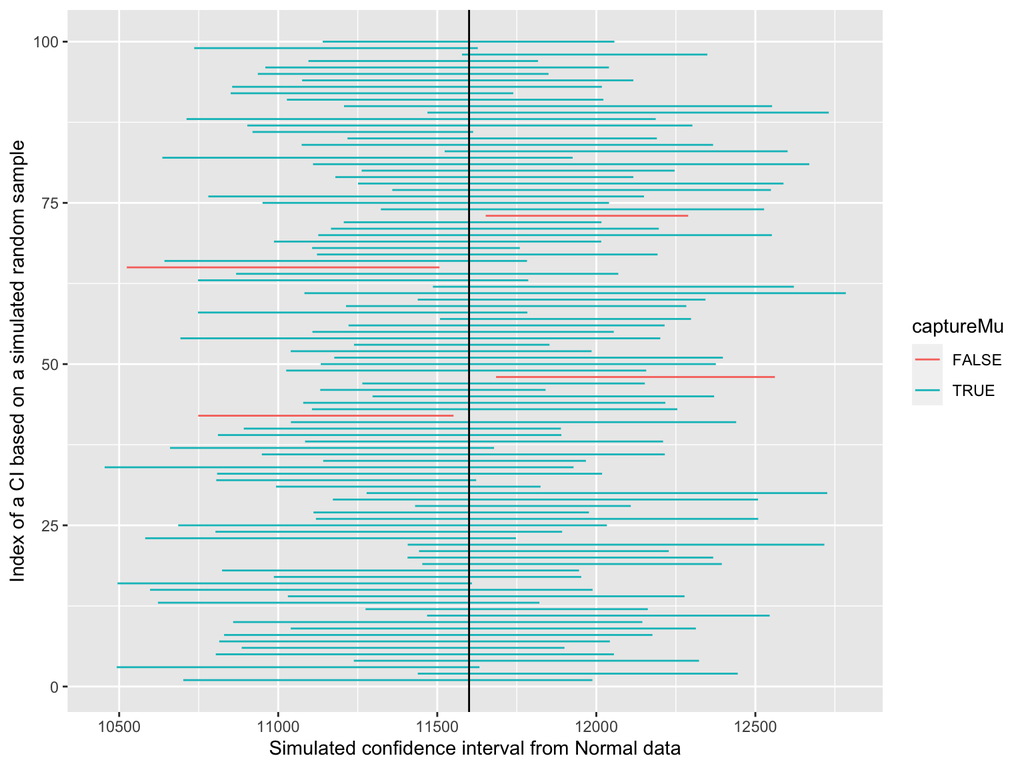

```r
# let's plot it!
library(tidyverse)

ConfIntDat %>%
  ggplot() +
  geom_segment(aes(    x = lower,    y = simulationID,
                    xend = upper, yend = simulationID,
                   color = captureMu)) +
  geom_vline(aes(xintercept = mu)) +
  xlab("Simulated confidence interval from Normal data") +
  ylab("Index of a CI based on a simulated random sample")
```

```r
# how often did our 95% CI actually capture mu? Easy!

mean(ConfIntDat$captureMu)
```

```
## [1] 0.96
```

- Can you see why we call it a “95% confidence interval”?
- Tinker with the simulation settings and try again
  - Explore changes to `nsimulations`, `mu`, `sigma`, and `sampleSize`
  - Try changing one at a time to larger or smaller values and observe what happens

# another way… (some would say “The R Way”)

- we can make a function that handles the guts of the loop and then call the function as an argument
- then we can leverage more efficient tools to do things way faster (vectorized functions, parallel processing, etc)

### Here’s the original code…

```
# simulation settings
nsimulations <- 100
mu <- 34
sigma <- 5
sampleSize <- 15

# initialize a data frame where we can store various results at each step in our simulation
ConfIntDat <- data.frame(simulationID = rep(NA, nsimulations),
                         lower = rep(NA, nsimulations),
                         upper = rep(NA, nsimulations),
                         captureMu = rep(NA, nsimulations))

# use a loop to simulate many results and store them at each step
for (i in 1:nsimulations) {                                   # increment 'i' from 1 to 'nsimulations'
  normDatSim <- rnorm(n = sampleSize, mean = mu, sd = sigma)  # simulate a new random sample
  ConfIntDat$simulationID[i] <- i                             # store an ID for each sample
  ConfIntDat$lower[i] <- t.test(normDatSim)$conf.int[1]       # store the lower bound of our CI
  ConfIntDat$upper[i] <- t.test(normDatSim)$conf.int[2]       # store upper bound of our CI
  ConfIntDat$captureMu[i] <- (mu > ConfIntDat$lower[i] & mu < ConfIntDat$upper[i])

}
```

### making a function…

- the simulation settings will be arguments we (or another user) might want to change
- when in doubt, it’s better to program arguments rather than “hard code” specific values within the guts of the function

```r
ciSim <- function(mu, sigma, sampleSize) {
  ## Purpose: function simulates random Normal data and constructs a 95% CI
  ## Arguments:
  ##    mu: population mean for Normal distribution from which samples are drawn
  ##    sigma: population standard deviation for Normal distribution from which samples are drawn
  ##    sampleSize: sample size to draw from Normal distribution

  result <- list(NULL)
  normDatSim <- rnorm(n = sampleSize, mean = mu, sd = sigma)  # simulate a new random sample
  result[1] <- t.test(normDatSim)$conf.int[1]                 # store lower bound of CI
  result[2] <- t.test(normDatSim)$conf.int[2]                 # store upper bound of CI
  result[3] <- (mu > result[1] & mu < result[2])              # store mu capture result
  return(result)                                              # return our results
}

ciSim(mu = 34, sigma = 5, sampleSize = 15)
```

```
## [[1]]
## [1] 31.04923
##
## [[2]]
## [1] 37.9274
##
## [[3]]
## [1] TRUE
```

### let’s use mosaic::do() which can “do” something many times without writing a loop

```r
library(mosaic)
sim_results <- mosaic::do(100) * ciSim(mu = 34, sigma = 5, sampleSize = 15)
sim_results
```

```
##           V1       V2    V3
## 1   31.40199 36.03148  TRUE
## 2   31.67241 36.72415  TRUE
## 3    31.9083 39.33292  TRUE
## 4   31.37299 36.34599  TRUE
## 5   33.51522 38.85687  TRUE
## 6   30.83769  36.1575  TRUE
## 7   29.26429 34.51992  TRUE
## 8    30.8558 35.80669  TRUE
## 9   32.86902 37.87525  TRUE
## 10  31.41081 36.66909  TRUE
## 11  29.00259 33.40962 FALSE
## 12   32.1703 36.16842  TRUE
## 13  32.90387 38.16764  TRUE
## 14  32.22272 37.95371  TRUE
```

[output cut: 86 more lines]

```r
# some handy tricks to get things into a data frame as desired
sim_results_df <-
  sim_results %>%
  transmute(lower = unlist(V1),    # unlist() simplifies to the object class inside the list element
            upper = unlist(V2),
            muCapture = unlist(V3)) %>%
  rownames_to_column() %>%    # handy function to create a column that indexes each row
  mutate(rowname = parse_number(rowname))

sim_results_df
```

```
##     rowname    lower    upper muCapture
## 1         1 31.40199 36.03148      TRUE
## 2         2 31.67241 36.72415      TRUE
## 3         3 31.90830 39.33292      TRUE
## 4         4 31.37299 36.34599      TRUE
## 5         5 33.51522 38.85687      TRUE
## 6         6 30.83769 36.15750      TRUE
## 7         7 29.26429 34.51992      TRUE
## 8         8 30.85580 35.80669      TRUE
## 9         9 32.86902 37.87525      TRUE
## 10       10 31.41081 36.66909      TRUE
## 11       11 29.00259 33.40962     FALSE
## 12       12 32.17030 36.16842      TRUE
## 13       13 32.90387 38.16764      TRUE
## 14       14 32.22272 37.95371      TRUE
```

[output cut: 86 more lines]

### plot it

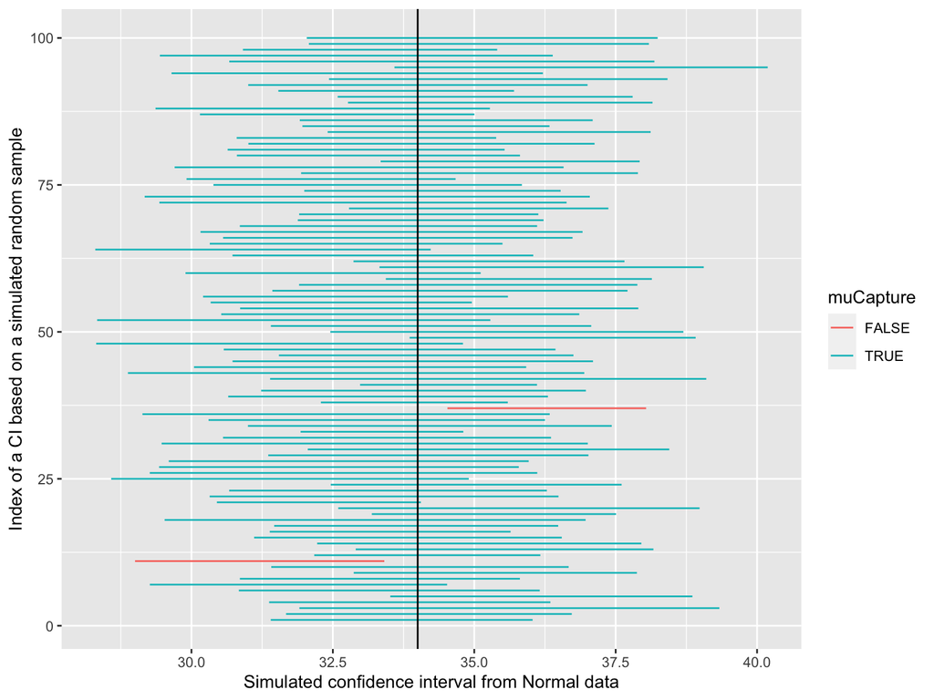

```r
sim_results_df %>%
  ggplot() +
  geom_segment(aes(    x = lower,    y = rowname,
                    xend = upper, yend = rowname,
                   color = muCapture)) +
  geom_vline(aes(xintercept = 34)) +      # mu reference is hard coded here because mu wasn't returned by `ciSim()`
  xlab("Simulated confidence interval from Normal data") +
  ylab("Index of a CI based on a simulated random sample")
```

```r
# how often did our 95% CI actually capture mu? Easy!

mean(sim_results_df$muCapture)
```

```
## [1] 0.98
```